# An analysis of Road Home grant funding in New Orleans

```python
from IPython.display import HTML

HTML('''<script>
code_show=true;
function code_toggle() {
 if (code_show){
 $('div.input').hide();
 } else {
 $('div.input').show();
 }
 code_show = !code_show
}
$( document ).ready(code_toggle);
</script>
<form action="javascript:code_toggle()"><input type="submit" value="Click here to toggle on/off the raw code."></form>''')
```

```python
import pandas as pd
import geopandas as gpd
import matplotlib.pyplot as plt
import seaborn as sns
plt.style.use('style/advocate.mplstyle')
%matplotlib inline
pd.set_option('display.float_format', lambda x: f'{x:,.2f}')
pd.set_option('display.max_rows', 100)
pd.set_option('display.max_columns', 100)
```

```python
rh_blocks_nola = gpd.read_file('processed data/rh_blocks_nola_flood_GT3.geojson')
rh_neighborhoods = gpd.read_file('processed data/rh_neighborhoods_flood_GT3.geojson')
rh_neighborhoods = rh_neighborhoods.rename(columns = {'index' : 'neighborhood'})
rh_neighborhoods = rh_neighborhoods.set_index('neighborhood')
```

Terminology:

- Blocks: Census Blocks based on boundaries and demographics based on 2000 Tiger/Line. Only blocks that received more than 3 feet of flooding are considered in this analysis.
- Neighborhoods: Neighborhood Statistical Areas defined by The Data Center based on 2000 boundaries
- Damage: Damage as assessed by the Road Home program
- Uncovered damage: The amount by which the damage exceeded the amount of Road Home grants (CG and ACG) plus the amount of insurance

## Maps

Visual representation of the percentage of damage not covered by insurance or Road Home grants by Census block in New Orleans.

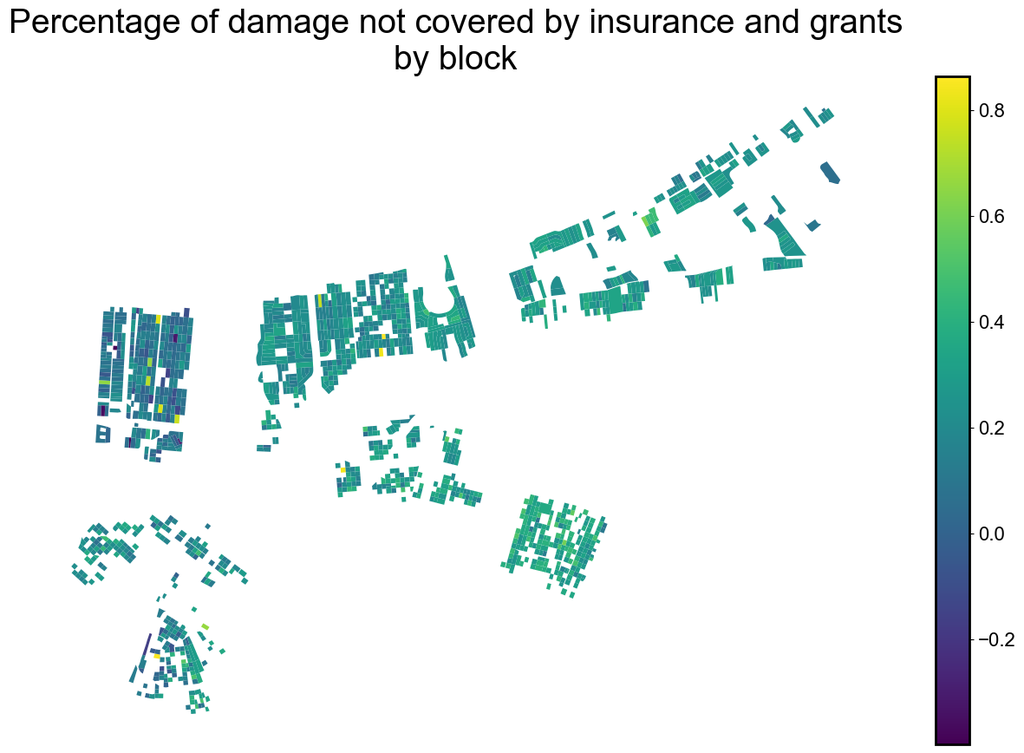

```python
fig, ax = plt.subplots(figsize=(17,10))
rh_blocks_nola.plot(column='uncovered_percent', ax=ax, legend=True)
plt.title('Percentage of damage not covered by insurance and grants\nby block')
plt.grid(False)
plt.axis('off')
plt.show()
plt.close()
```

Visual representation of the percentage of damage not covered by insurance or Road Home grants by Neighborhood Statistical Area in New Orleans.

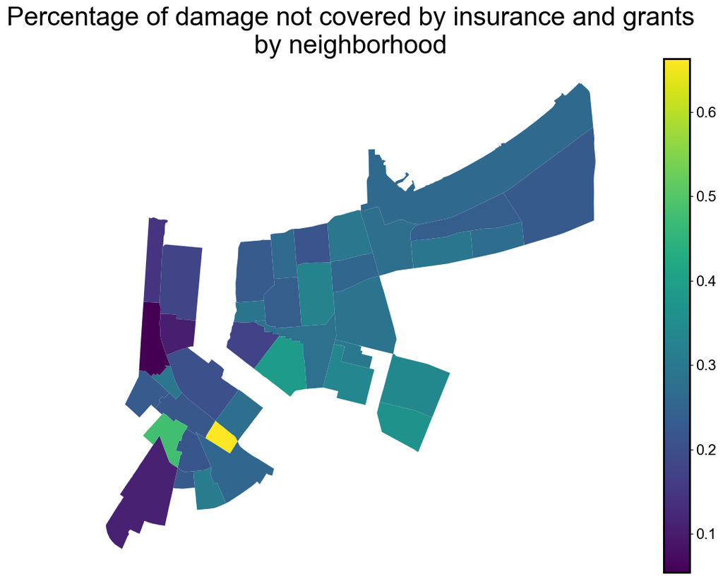

```python
fig, ax = plt.subplots(figsize=(17,10))
rh_neighborhoods.plot(column='uncovered_percent', ax=ax, legend=True)
plt.title('Percentage of damage not covered by insurance and grants\nby neighborhood')
plt.grid(False)
plt.axis('off')
plt.show()
plt.close()
```

### Percent of uncovered damage by blocks and neighborhoods

There is a negative correlation between the percentage of a block's populaton that is non-Hispanic White and the percentage of damage that was not covered by the Road Home program in New Orleans.

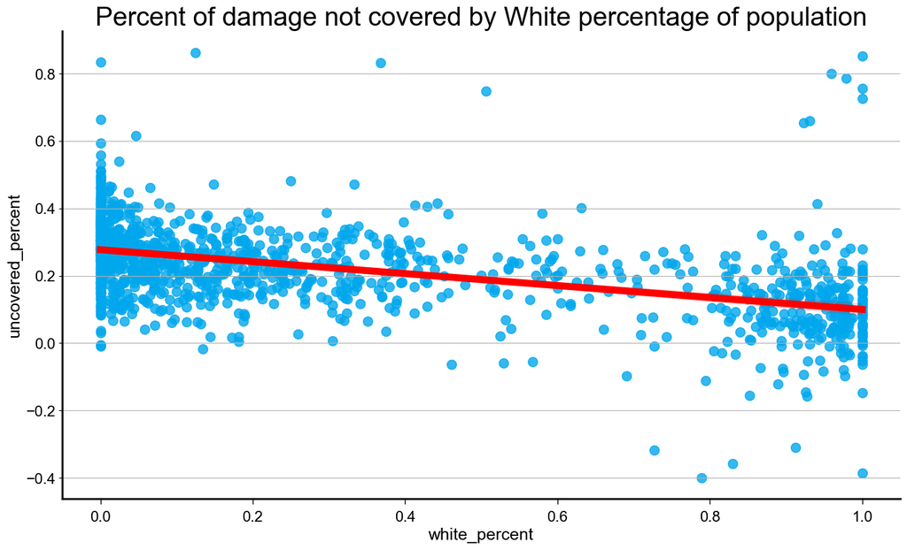

```python
fig, ax = plt.subplots()
sns.regplot(rh_blocks_nola, x='white_percent', y='uncovered_percent', line_kws={'color' : 'red'}, ax=ax)
plt.title('Percent of damage not covered by White percentage of population')
plt.show()
plt.close()
```

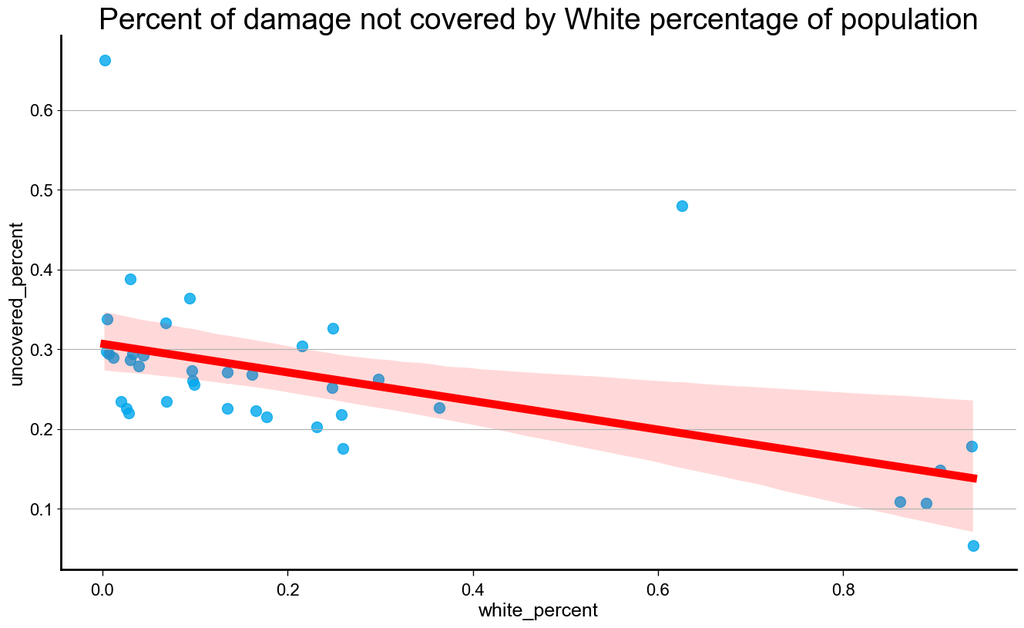

```python
fig, ax = plt.subplots()
sns.regplot(rh_neighborhoods, x='white_percent', y='uncovered_percent', line_kws={'color' : 'red'}, ax=ax)
plt.title('Percent of damage not covered by White percentage of population')
plt.show()
plt.close()
```

## Damage and compensation by neighborhood

```python
(
    rh_neighborhoods[rh_neighborhoods['damage_sum']>0][
        [   'damage_sum',
            'grant_insurance_sum',
            'grant_insurance_mean',
            'uncovered_sum',
            'uncovered_mean',
            'uncovered_percent',
            'white_percent',
            'rh_household_pct',
            'households_2000_owner_occupied_pct'
    ]
]
.sort_values(by='uncovered_percent')
)
```

| neighborhood | damage_sum | grant_insurance_sum | grant_insurance_mean | uncovered_sum | uncovered_mean | uncovered_percent | white_percent | rh_household_pct | households_2000_owner_occupied_pct |
| --- | --- | --- | --- | --- | --- | --- | --- | --- | --- |
| LAKEWOOD | 27,771,533.61 | 26,263,319.71 | 295,093.48 | 1,508,213.90 | 16,946.22 | 0.05 | 0.94 | 0.12 | 0.92 |
| NAVARRE | 83,730,193.27 | 74,803,993.60 | 200,546.90 | 8,926,199.67 | 23,930.83 | 0.11 | 0.89 | 0.45 | 0.56 |
| AUDUBON | 8,179,229.39 | 7,286,615.12 | 177,722.32 | 892,614.27 | 21,771.08 | 0.11 | 0.86 | 0.01 | 0.54 |
| WEST END | 172,131,805.43 | 146,596,840.34 | 225,187.16 | 25,534,965.09 | 39,224.22 | 0.15 | 0.91 | 0.43 | 0.61 |
| FAIRGROUNDS | 11,788,571.47 | 9,722,515.90 | 151,914.31 | 2,066,055.57 | 32,282.12 | 0.18 | 0.26 | 0.05 | 0.44 |
| LAKEVIEW | 541,337,816.08 | 444,920,096.69 | 241,410.80 | 96,417,719.39 | 52,315.64 | 0.18 | 0.94 | 0.59 | 0.69 |
| MID-CITY | 77,964,112.26 | 62,173,136.69 | 161,909.21 | 15,790,975.57 | 41,122.33 | 0.20 | 0.23 | 0.24 | 0.28 |
| MILNEBURG | 228,037,851.97 | 178,849,611.80 | 162,442.88 | 49,188,240.17 | 44,675.97 | 0.22 | 0.18 | 0.70 | 0.71 |
| BROADMOOR | 152,938,541.39 | 119,575,253.06 | 170,578.11 | 33,363,288.33 | 47,593.85 | 0.22 | 0.26 | 0.50 | 0.48 |
| GERT TOWN | 10,037,677.59 | 7,832,419.65 | 150,623.45 | 2,205,257.94 | 42,408.81 | 0.22 | 0.03 | 0.14 | 0.24 |
| READ BLVD EAST | 101,694,894.98 | 78,993,695.29 | 197,484.24 | 22,701,199.69 | 56,753.00 | 0.22 | 0.17 | 0.16 | 0.89 |
| FRERET | 7,445,412.90 | 5,766,907.19 | 144,172.68 | 1,678,505.71 | 41,962.64 | 0.23 | 0.13 | 0.13 | 0.35 |
| HOLLYGROVE | 111,547,282.41 | 86,345,797.88 | 143,193.69 | 25,201,484.53 | 41,793.51 | 0.23 | 0.03 | 0.42 | 0.54 |
| FILMORE | 356,220,860.84 | 275,515,399.24 | 192,399.02 | 80,705,461.60 | 56,358.56 | 0.23 | 0.36 | 0.61 | 0.86 |
| WEST LAKE FOREST | 79,853,709.52 | 61,151,459.98 | 155,206.75 | 18,702,249.54 | 47,467.64 | 0.23 | 0.02 | 0.46 | 0.24 |
| DILLARD | 76,616,382.80 | 58,646,705.83 | 155,150.02 | 17,969,676.97 | 47,538.83 | 0.23 | 0.07 | 0.25 | 0.58 |
| GENTILLY WOODS | 109,382,118.72 | 81,775,371.38 | 153,424.71 | 27,606,747.34 | 51,795.02 | 0.25 | 0.25 | 0.48 | 0.76 |
| CENTRAL CITY | 7,926,177.48 | 5,894,869.97 | 140,354.05 | 2,031,307.51 | 48,364.46 | 0.26 | 0.10 | 0.03 | 0.16 |
| LITTLE WOODS | 410,022,885.98 | 303,212,398.91 | 183,765.09 | 106,810,487.07 | 64,733.63 | 0.26 | 0.10 | 0.20 | 0.51 |
| ST. ANTHONY | 193,177,555.56 | 142,529,243.50 | 159,965.48 | 50,648,312.06 | 56,844.35 | 0.26 | 0.30 | 0.69 | 0.57 |
| READ BLVD WEST | 68,855,697.96 | 50,366,564.15 | 163,527.81 | 18,489,133.81 | 60,029.66 | 0.27 | 0.16 | 0.18 | 0.85 |
| TULANE - GRAVIER | 3,145,334.04 | 2,290,765.44 | 143,172.84 | 854,568.60 | 53,410.54 | 0.27 | 0.13 | 0.05 | 0.19 |
| PINES VILLAGE | 98,605,329.45 | 71,623,807.52 | 162,412.26 | 26,981,521.93 | 61,182.59 | 0.27 | 0.10 | 0.41 | 0.64 |
| ST. ROCH | 120,167,376.65 | 86,691,581.06 | 145,212.03 | 33,475,795.59 | 56,073.36 | 0.28 | 0.04 | 0.33 | 0.42 |
| DESIRE AREA | 33,342,740.54 | 23,768,639.85 | 121,890.46 | 9,574,100.69 | 49,097.95 | 0.29 | 0.03 | 0.28 | 0.44 |
| ST. BERNARD AREA | 22,470,401.52 | 15,970,399.90 | 138,873.04 | 6,500,001.62 | 56,521.75 | 0.29 | 0.01 | 0.33 | 0.17 |
| PLUM ORCHARD | 114,374,505.92 | 80,947,588.39 | 150,181.05 | 33,426,917.53 | 62,016.54 | 0.29 | 0.04 | 0.38 | 0.57 |
| PONTCHARTRAIN PARK | 131,859,028.07 | 93,025,280.36 | 149,318.27 | 38,833,747.71 | 62,333.46 | 0.29 | 0.01 | 0.67 | 0.92 |
| DIXON | 22,145,379.08 | 15,618,397.45 | 137,003.49 | 6,526,981.63 | 57,254.22 | 0.29 | 0.03 | 0.41 | 0.42 |
| FLORIDA AREA | 69,672,798.57 | 48,928,118.29 | 134,417.91 | 20,744,680.28 | 56,990.88 | 0.30 | 0.00 | 0.52 | 0.58 |
| MILAN | 26,286,883.95 | 18,285,450.87 | 147,463.31 | 8,001,433.08 | 64,527.69 | 0.30 | 0.22 | 0.12 | 0.33 |
| GENTILLY TERRACE | 147,571,969.72 | 99,461,807.02 | 163,588.50 | 48,110,162.70 | 79,128.56 | 0.33 | 0.25 | 0.21 | 0.69 |
| ST. CLAUDE | 6,527,988.88 | 4,354,433.00 | 120,956.47 | 2,173,555.88 | 60,376.55 | 0.33 | 0.07 | 0.02 | 0.45 |
| LOWER NINTH WARD | 337,987,944.88 | 223,840,174.83 | 130,291.14 | 114,147,770.05 | 66,442.24 | 0.34 | 0.00 | 0.60 | 0.59 |
| HOLY CROSS | 4,855,906.28 | 3,086,554.51 | 134,198.02 | 1,769,351.77 | 76,928.34 | 0.36 | 0.09 | 0.03 | 0.42 |
| SEVENTH WARD | 56,115,049.99 | 34,322,496.08 | 140,091.82 | 21,792,553.91 | 88,949.20 | 0.39 | 0.03 | 0.11 | 0.33 |
| MARLYVILLE - FONTAINEBLEAU | 21,442,269.22 | 11,152,628.06 | 189,027.59 | 10,289,641.16 | 174,400.70 | 0.48 | 0.63 | 0.04 | 0.52 |
| B. W. COOPER | 1,628,017.82 | 548,553.79 | 91,425.63 | 1,079,464.03 | 179,910.67 | 0.66 | 0.00 | 0.11 | 0.04 |

## Additional Compensation Grants

The additional compensation grants did have an impact, particularly in neighborhoods with large amounts of damage that was not covered. But even with those grants, there were still large amounts of damage that went uncovered

```python
wo_acg = rh_neighborhoods[rh_neighborhoods['damage_sum']>0][['compensation_sum', 'insurance_sum', 'damage_sum', 'all_grants_count']].apply(lambda x: (x['damage_sum'] - (x['compensation_sum']+x['insurance_sum']))/x['damage_sum'], axis=1).sort_values(ascending=False)
w_acg = rh_neighborhoods[rh_neighborhoods['damage_sum']>0]['uncovered_percent']

acg_compare = pd.concat([wo_acg.rename('Without ACG'), w_acg.rename('With ACG')], axis=1)
acg_compare['Difference'] = acg_compare['Without ACG'] - acg_compare['With ACG']
acg_compare.sort_values(by="Difference")
```

| neighborhood | Without ACG | With ACG | Difference |
| --- | --- | --- | --- |
| LAKEWOOD | 0.06 | 0.05 | 0.00 |
| AUDUBON | 0.11 | 0.11 | 0.00 |
| MARLYVILLE - FONTAINEBLEAU | 0.49 | 0.48 | 0.01 |
| LAKEVIEW | 0.19 | 0.18 | 0.01 |
| WEST END | 0.17 | 0.15 | 0.02 |
| NAVARRE | 0.13 | 0.11 | 0.02 |
| FILMORE | 0.29 | 0.23 | 0.07 |
| FRERET | 0.30 | 0.23 | 0.07 |
| GENTILLY TERRACE | 0.41 | 0.33 | 0.09 |
| BROADMOOR | 0.31 | 0.22 | 0.09 |
| LITTLE WOODS | 0.36 | 0.26 | 0.10 |
| READ BLVD EAST | 0.32 | 0.22 | 0.10 |
| MID-CITY | 0.30 | 0.20 | 0.10 |
| ST. ANTHONY | 0.37 | 0.26 | 0.11 |
| MILNEBURG | 0.33 | 0.22 | 0.12 |
| B. W. COOPER | 0.78 | 0.66 | 0.12 |
| MILAN | 0.42 | 0.30 | 0.12 |
| FAIRGROUNDS | 0.30 | 0.18 | 0.13 |
| TULANE - GRAVIER | 0.41 | 0.27 | 0.14 |
| DILLARD | 0.38 | 0.23 | 0.15 |
| PONTCHARTRAIN PARK | 0.44 | 0.29 | 0.15 |
| READ BLVD WEST | 0.42 | 0.27 | 0.15 |
| GENTILLY WOODS | 0.41 | 0.25 | 0.16 |
| ST. BERNARD AREA | 0.46 | 0.29 | 0.17 |
| PINES VILLAGE | 0.45 | 0.27 | 0.17 |
| HOLY CROSS | 0.54 | 0.36 | 0.17 |
| SEVENTH WARD | 0.57 | 0.39 | 0.18 |
| WEST LAKE FOREST | 0.42 | 0.23 | 0.18 |
| PLUM ORCHARD | 0.48 | 0.29 | 0.18 |
| DIXON | 0.49 | 0.29 | 0.19 |
| HOLLYGROVE | 0.42 | 0.23 | 0.20 |
| LOWER NINTH WARD | 0.55 | 0.34 | 0.21 |
| GERT TOWN | 0.44 | 0.22 | 0.22 |
| CENTRAL CITY | 0.48 | 0.26 | 0.22 |
| ST. ROCH | 0.50 | 0.28 | 0.23 |
| ST. CLAUDE | 0.58 | 0.33 | 0.25 |
| FLORIDA AREA | 0.56 | 0.30 | 0.27 |
| DESIRE AREA | 0.56 | 0.29 | 0.28 |

```python
rh_neighborhoods[['uncovered_mean', 'white_percent']].dropna(axis=0, subset='uncovered_mean').sort_values(by='uncovered_mean', ascending=False)
```

| neighborhood | uncovered_mean | white_percent |
| --- | --- | --- |
| B. W. COOPER | 179,910.67 | 0.00 |
| MARLYVILLE - FONTAINEBLEAU | 174,400.70 | 0.63 |
| SEVENTH WARD | 88,949.20 | 0.03 |
| GENTILLY TERRACE | 79,128.56 | 0.25 |
| HOLY CROSS | 76,928.34 | 0.09 |
| LOWER NINTH WARD | 66,442.24 | 0.00 |
| LITTLE WOODS | 64,733.63 | 0.10 |
| MILAN | 64,527.69 | 0.22 |
| PONTCHARTRAIN PARK | 62,333.46 | 0.01 |
| PLUM ORCHARD | 62,016.54 | 0.04 |
| PINES VILLAGE | 61,182.59 | 0.10 |
| ST. CLAUDE | 60,376.55 | 0.07 |
| READ BLVD WEST | 60,029.66 | 0.16 |
| DIXON | 57,254.22 | 0.03 |
| FLORIDA AREA | 56,990.88 | 0.00 |
| ST. ANTHONY | 56,844.35 | 0.30 |
| READ BLVD EAST | 56,753.00 | 0.17 |
| ST. BERNARD AREA | 56,521.75 | 0.01 |
| FILMORE | 56,358.56 | 0.36 |
| ST. ROCH | 56,073.36 | 0.04 |
| TULANE - GRAVIER | 53,410.54 | 0.13 |
| LAKEVIEW | 52,315.64 | 0.94 |
| GENTILLY WOODS | 51,795.02 | 0.25 |
| DESIRE AREA | 49,097.95 | 0.03 |
| CENTRAL CITY | 48,364.46 | 0.10 |
| BROADMOOR | 47,593.85 | 0.26 |
| DILLARD | 47,538.83 | 0.07 |
| WEST LAKE FOREST | 47,467.64 | 0.02 |
| MILNEBURG | 44,675.97 | 0.18 |
| GERT TOWN | 42,408.81 | 0.03 |
| FRERET | 41,962.64 | 0.13 |
| HOLLYGROVE | 41,793.51 | 0.03 |
| MID-CITY | 41,122.33 | 0.23 |
| WEST END | 39,224.22 | 0.91 |
| FAIRGROUNDS | 32,282.12 | 0.26 |
| NAVARRE | 23,930.83 | 0.89 |
| AUDUBON | 21,771.08 | 0.86 |
| LAKEWOOD | 16,946.22 | 0.94 |

```python
rh_neighborhoods[['all_grants_count', 'damage_mean', 'uncovered_percent', 'white_percent']].dropna(axis=0, subset='damage_mean').sort_values(by='damage_mean')
```

| neighborhood | all_grants_count | damage_mean | uncovered_percent | white_percent |
| --- | --- | --- | --- | --- |
| DESIRE AREA | 195.00 | 170,988.41 | 0.29 | 0.03 |
| ST. CLAUDE | 36.00 | 181,333.02 | 0.33 | 0.07 |
| FAIRGROUNDS | 64.00 | 184,196.43 | 0.18 | 0.26 |
| HOLLYGROVE | 603.00 | 184,987.20 | 0.23 | 0.03 |
| FRERET | 40.00 | 186,135.32 | 0.23 | 0.13 |
| CENTRAL CITY | 42.00 | 188,718.51 | 0.26 | 0.10 |
| FLORIDA AREA | 364.00 | 191,408.79 | 0.30 | 0.00 |
| GERT TOWN | 52.00 | 193,032.26 | 0.22 | 0.03 |
| DIXON | 114.00 | 194,257.71 | 0.29 | 0.03 |
| ST. BERNARD AREA | 115.00 | 195,394.80 | 0.29 | 0.01 |
| TULANE - GRAVIER | 16.00 | 196,583.38 | 0.27 | 0.13 |
| LOWER NINTH WARD | 1,718.00 | 196,733.38 | 0.34 | 0.00 |
| AUDUBON | 41.00 | 199,493.40 | 0.11 | 0.86 |
| ST. ROCH | 597.00 | 201,285.39 | 0.28 | 0.04 |
| WEST LAKE FOREST | 394.00 | 202,674.39 | 0.23 | 0.02 |
| DILLARD | 378.00 | 202,688.84 | 0.23 | 0.07 |
| MID-CITY | 384.00 | 203,031.54 | 0.20 | 0.23 |
| GENTILLY WOODS | 533.00 | 205,219.73 | 0.25 | 0.25 |
| MILNEBURG | 1,101.00 | 207,118.85 | 0.22 | 0.18 |
| HOLY CROSS | 23.00 | 211,126.36 | 0.36 | 0.09 |
| PONTCHARTRAIN PARK | 623.00 | 211,651.73 | 0.29 | 0.01 |
| MILAN | 124.00 | 211,991.00 | 0.30 | 0.22 |
| PLUM ORCHARD | 539.00 | 212,197.60 | 0.29 | 0.04 |
| ST. ANTHONY | 891.00 | 216,809.83 | 0.26 | 0.30 |
| BROADMOOR | 701.00 | 218,171.96 | 0.22 | 0.26 |
| READ BLVD WEST | 308.00 | 223,557.46 | 0.27 | 0.16 |
| PINES VILLAGE | 441.00 | 223,594.85 | 0.27 | 0.10 |
| NAVARRE | 373.00 | 224,477.73 | 0.11 | 0.89 |
| SEVENTH WARD | 245.00 | 229,041.02 | 0.39 | 0.03 |
| GENTILLY TERRACE | 608.00 | 242,717.06 | 0.33 | 0.25 |
| LITTLE WOODS | 1,650.00 | 248,498.72 | 0.26 | 0.10 |
| FILMORE | 1,432.00 | 248,757.58 | 0.23 | 0.36 |
| READ BLVD EAST | 400.00 | 254,237.24 | 0.22 | 0.17 |
| WEST END | 651.00 | 264,411.38 | 0.15 | 0.91 |
| B. W. COOPER | 6.00 | 271,336.30 | 0.66 | 0.00 |
| LAKEVIEW | 1,843.00 | 293,726.43 | 0.18 | 0.94 |
| LAKEWOOD | 89.00 | 312,039.70 | 0.05 | 0.94 |
| MARLYVILLE - FONTAINEBLEAU | 59.00 | 363,428.29 | 0.48 | 0.63 |